# Characterizing Automobiles

Author

Mike Kimmell

Published

March 20, 2025

# Setup

- Setup

```r
sh <- suppressPackageStartupMessages
sh(library(tidyverse))
sh(library(caret))
sh(library(fastDummies))
sh(library(class))
sh(library(ISLR)) # for the "Auto" dataframe\
sh(library(pROC)) # for ROC
```

# Dataframe

- We use the `Auto` dataframe.

```r
head(Auto)
```

```
  mpg cylinders displacement horsepower weight acceleration year origin
1  18         8          307        130   3504         12.0   70      1
2  15         8          350        165   3693         11.5   70      1
3  18         8          318        150   3436         11.0   70      1
4  16         8          304        150   3433         12.0   70      1
5  17         8          302        140   3449         10.5   70      1
6  15         8          429        198   4341         10.0   70      1
                       name
1 chevrolet chevelle malibu
2         buick skylark 320
3        plymouth satellite
4             amc rebel sst
5               ford torino
6          ford galaxie 500
```

- It has the following variable names, which describe various attributes of automobiles.

```r
names(Auto)
```

```
[1] "mpg"          "cylinders"    "displacement" "horsepower"   "weight"
[6] "acceleration" "year"         "origin"       "name"
```

# Multiple Regression

- Run a linear regression model with `mpg` as the dependent variable and `horsepower` and `year` as features (variables).
- Compute and comment on the RMSE.

```r
m1 = lm(mpg ~ horsepower, Auto)
m2 = lm(mpg ~ year, Auto)
m3 = lm(mpg ~ horsepower + year, Auto)
m4 = lm(mpg ~ horsepower * year, Auto)
m5 = lm(mpg ~ ., Auto)

get_rmse <- function(m) {
    pred <- predict(m, newdata = Auto)
    sqrt(mean((Auto$mpg - pred)^2))
}

unlist(lapply(list(m1, m2, m3, m4, m5), get_rmse))
```

```
[1] 4.893226 6.346968 4.371506 3.880584 1.057928
```

> In this dataset, our mpg field has a minimum of 9 and a maximum of 46, giving us a range of only 37 mpg. Model 2, which goes off only the Year feature, has an RMSE of ~6, which means that we have almost 16% error in our prediction. I would consider this an unacceptably high RMSE for the data we are looking at. Model 4 comes closer to describing the data with an RMSE of ~4, which is still not great. Ultimately, a model that looks at all the available data, Model 5, is only off by about 1 mpg, which I would argue is pretty darn good.

# Feature Engineering

- Create 10 features based on the `name` column.
- Remove all rows with a missing value.
- Ensure only `mpg` and the engineered features remain.
- Compute and comment on the RMSE.

```r
auto_all <- Auto %>% #Let's make some dummy variables using 'Make's
  mutate(amc = str_detect(name,"amc")) %>%
  mutate(buick = str_detect(name,"buick")) %>%
  mutate(chev = str_detect(name,"chev")) %>%
  mutate(datsun = str_detect(name,"datsun")) %>%
  mutate(dodge = str_detect(name,"dodge")) %>%
  mutate(ford = str_detect(name,"ford")) %>%
  mutate(honda = str_detect(name,"honda")) %>%
  mutate(mazda = str_detect(name,"mazda")) %>%
  mutate(plym = str_detect(name,"plym")) %>%
  mutate(toyota = str_detect(name,"toyota"))

auto_feat <- na.omit(auto_all) %>%
  select(mpg,amc,buick,chev,datsun,dodge,ford,honda,mazda,plym,toyota)

sqrt(mean((auto_feat$mpg - predict(lm(formula = mpg ~ ., data = auto_feat), newdata = auto_feat))^2))
```

```
[1] 6.63807
```

> Trying to determine the mpg of these vehciles, just using 10 of the most popular ‘Make’s proves to be an even worse predictor than just using the ’Year’ variable. I believe that this makes intuitive sense. While many like to draw anectdotal conclusions about the gas efficiency of certain ’Make’s, it’s logically going to be more reliant on the physical/numeric characteristics of the vehicle.

# Classification

- Use either of $K$-NN or Naive Bayes to predict whether an automobile is a `chevrolet` or a `honda`.
- Explain your choice of technique.
- Report on your Kappa value.

```r
control = trainControl(method = "cv", number = 5)

auto_knn = auto_all %>%
  filter(chev == 1 | honda == 1) %>%
  mutate(origin = as.factor(origin)) %>% #This will get us Chevy vs Honda easily
  select(mpg, cylinders, displacement, horsepower, weight, acceleration, year, origin)

split <- createDataPartition(auto_knn$origin, p = 0.8, list = FALSE)
train_knn <- auto_knn[split, ]
test_knn <- auto_knn[-split, ]

fit_knn = train(origin ~ .,
                data = train_knn,
                method = "knn",
                tuneLength = 15,
                metric = "Kappa",
                trControl = control)

confusionMatrix(predict(fit_knn, test_knn),factor(test_knn$origin))
```

```
Confusion Matrix and Statistics

          Reference
Prediction 1 3
         1 8 1
         3 1 1

               Accuracy : 0.8182
                 95% CI : (0.4822, 0.9772)
    No Information Rate : 0.8182
    P-Value [Acc > NIR] : 0.6776

                  Kappa : 0.3889

 Mcnemar's Test P-Value : 1.0000

            Sensitivity : 0.8889
            Specificity : 0.5000
         Pos Pred Value : 0.8889
         Neg Pred Value : 0.5000
             Prevalence : 0.8182
         Detection Rate : 0.7273
   Detection Prevalence : 0.8182
      Balanced Accuracy : 0.6944

       'Positive' Class : 1
```

> I used the Origin feature as the predictor for this model, because once it was filtered down to just Chevy and Honda vehicles, it should be immediately apparent to know that all Chevy’s would have a Origin of 1 (United States) and that all Hondas would have an origin of 3 (Japan). The first time I ran this data, it returned a Kappa value of 1, meaning I was able to fully predict whether a car was a Honda or a Chevy, all on the first try. This seemed rather dubious to me, so I ran this code 5-10 more times, and got an average Kappa value of ~0.62. While this isn’t a terrible Kappa value to have, I believe the results are hard to rely on, due to the small number of observations in our dataset. After filtering and splitting the data, we are only predicting 11 observations in our test dataset. While I chose KNN for its efficiency over smaller datasets, I believe that this dataset is just too small to have a reliable result.

# Binary Classification

- Predict whether a car is a `honda`.
- Use model weights.
- Display and comment on an ROC curve.

```r
auto_bin = auto_all %>%
  mutate(origin = as.factor(origin)) %>%
  mutate(honda = as.factor(honda)) %>%
  select(mpg, cylinders, displacement, horsepower, weight, acceleration, year, origin, honda)

split2 <- createDataPartition(auto_bin$honda, p = 0.8, list = FALSE)
train_bin <- auto_bin[split2, ]
test_bin <- auto_bin[-split2, ]

weight_train <- train_bin %>%
  mutate(weights=case_when(
    honda == TRUE ~ 29.15,
    honda == FALSE ~ 1))

fit_bin = train(honda ~ .,
               data = train_bin,
               method = "glm",
               family = "binomial",
               trControl = control,
               weights = weight_train$weights)
confusionMatrix(predict(fit_bin, test_bin),factor(test_bin$honda))
```

```
Confusion Matrix and Statistics

          Reference
Prediction FALSE TRUE
     FALSE    70    2
     TRUE      5    0

               Accuracy : 0.9091
                 95% CI : (0.8216, 0.9627)
    No Information Rate : 0.974
    P-Value [Acc > NIR] : 0.9991

                  Kappa : -0.0385

 Mcnemar's Test P-Value : 0.4497

            Sensitivity : 0.9333
            Specificity : 0.0000
         Pos Pred Value : 0.9722
         Neg Pred Value : 0.0000
             Prevalence : 0.9740
         Detection Rate : 0.9091
   Detection Prevalence : 0.9351
      Balanced Accuracy : 0.4667

       'Positive' Class : FALSE
```

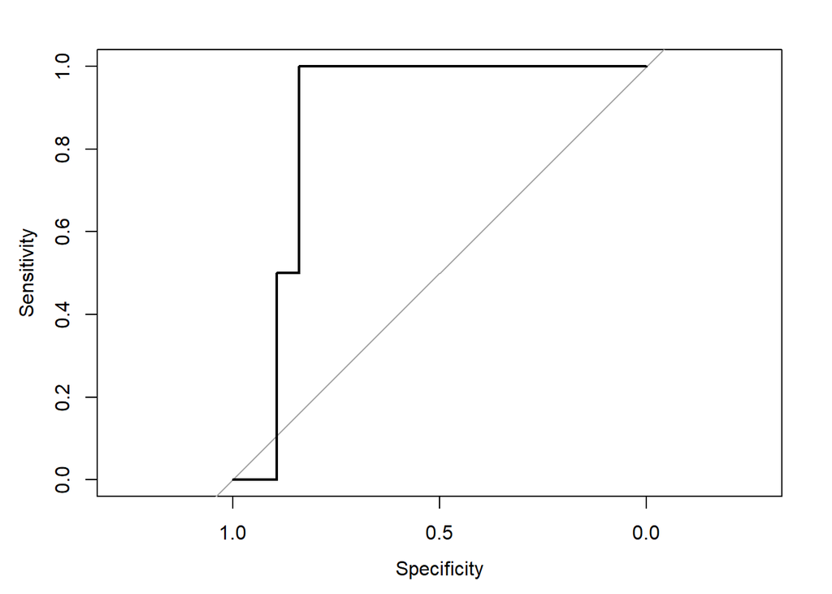

```r
prob <- predict(fit_bin, newdata = test_bin, type = "prob")[,2]
myRoc <- roc(test_bin$honda, prob)
plot(myRoc)
```